# WSP R Open Question Analysis

Lizzie Jones[^1]

02/05/2021

## Text analysis and visualisations for open questions

This rMarkdown explores and analyses the open questions using text, work frequency and sentiment analysis techniques which are beyond the scope of NVivo (or where R is more effective).

The key open-ended questions include:

- Q8. How did you feel when you saw WS in the wild?
- Q9a. [If respondent has heard of the white stork project and its efforts to reintroduce white storks to southern England], please briefly summarise what you have heard.
- Q11a-c. Three words used to describe white storks
- Q15. Do you support the White Stork Project?
- Q16. What are yours views on the management of White Storks?
- Q17.1-17.13. Which (if any) methods of white stork project management would you support?

In this rMarkdown script I clean and explore each question in turn in the sections below, visualise the data and comment on any interesting findings.

### Q8. How did you feel when you saw white stork in the wild?

Question options - “Seen in the UK”, “Seen outside the UK”. Respondents were then asked if they wanted to explain/elaborate on their answer using an open-ended question.

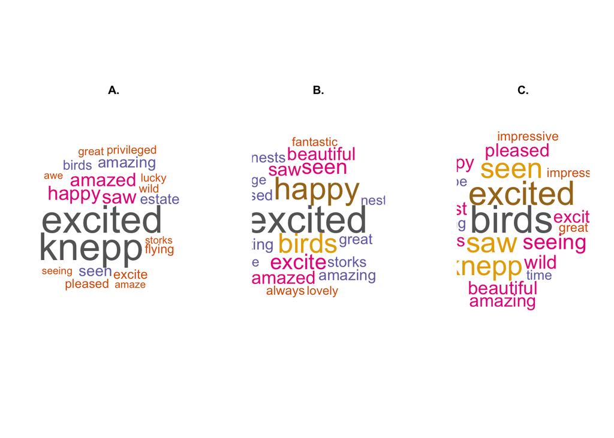

```r
#Creating a non-local/local factor column for proximity to any WS release site
final_data <- mutate(final_data, SiteProximity =
                       ifelse(ReleaseSite == "No", "Not local", "Local"))
### Q8. How did you feel when you saw WS in the wild?
# Create words df to seperately clean, capitalise first letter etc
feel_df <- final_data %>%
  dplyr::select(UniqueID_all, SurveyType, Q8.WhereSeen, Q8.2_feelings)

# feel_syns <- qdap::synonyms(feel_df$Q8.2_feelings)

### Create two dataframes: one for each data collection for easier comparison
feelings_UK <- feel_df[which(feel_df$Q8.WhereSeen == "UK"),]
feelings_nonUK <- feel_df[which(feel_df$Q8.WhereSeen == "OutsideUK"),]
feelings_both <- feel_df[which(feel_df$Q8.WhereSeen == "Both"),]

# Create the custom function that will be used to clean the corpus: clean_coupus
clean_corpus_feel <- function(corpus){
  corpus <- tm_map(corpus, stripWhitespace)
  corpus <- tm_map(corpus, removePunctuation)
  corpus <- tm_map(corpus, content_transformer(tolower))
  corpus <- tm_map(corpus, removeWords, stopwords("en"))
  corpus <- tm_map(corpus, lemmatize_words)
    return(corpus)
}

# Seen in the wild within the UK (n=472)
corpus_seenUK <- Corpus(VectorSource(feelings_UK$Q8.2_feelings))
corpus_seenUK_clean <- clean_corpus_feel(corpus_seenUK)
corpus_seenUK_clean <- tm_map(corpus_seenUK_clean, removeWords,
                   c("they", "the", "the ", "its", "also", "I'm", "don't"," see", "can","see ","white",
                     "think", "one", "really", "bird", "see", "stork", "feel", "was"))
# Seen in the wild outside the UK (n=671)
corpus_seen_nonUK <- Corpus(VectorSource(feelings_nonUK$Q8.2_feelings))
corpus_seen_nonUK_clean <- clean_corpus_feel(corpus_seen_nonUK)
corpus_seen_nonUK_clean <- tm_map(corpus_seen_nonUK_clean, removeWords,
                   c("they", "the", "the ", "its", "also", "I'm", "don't"," see", "can","see ","white",
                     "think", "one", "really", "bird", "see", "stork", "feel", "was"))
# Seen in the wild in the UK and outside the UK (n=299)
corpus_seen_both <- Corpus(VectorSource(feelings_both$Q8.2_feelings))
corpus_seen_both_clean <- clean_corpus_feel(corpus_seen_both)
corpus_seen_both_clean <- tm_map(corpus_seen_both_clean, removeWords,
                   c("they", "the", "the ", "its", "also", "I'm", "don't"," see", "can","see ","white",
                     "think", "one", "really", "bird", "see", "stork", "feel", "was"))

## Plot image and save as a PDF using the file viewer
par(mfrow=c(1,3))
wordcloud(corpus_seenUK_clean, max.words=20, random.order=FALSE, rot.per=0,
          use.r.layout=FALSE, colors=brewer.pal(8, "Dark2"))
title(main="A.",col="black",font=2,line=-4)

wordcloud(corpus_seen_nonUK_clean, max.words=20, random.order=FALSE, rot.per=0,
          use.r.layout=FALSE, colors=brewer.pal(8, "Dark2"))
title(main="B.",col="black",font=2,line=-4)
wordcloud(corpus_seen_both_clean, max.words=20, random.order=FALSE, rot.per=0,
          use.r.layout=FALSE, colors=brewer.pal(8, "Dark2"))
title(main="C.",col="black",font=2,line=-4)
```

### Q11. What descriptive words do you associate with white storks?

```r
# Words used to describe WS - will probably combine into one column, labelled by Respondent ID and SurveyType
summary(final_data$Q11_word1)
```

```
##                     Large         Rare      Elegant    Beautiful          Big
##          670          296          208          152          151          145
##        White     Majestic         Bird         Tall   Beautiful      Graceful
##          121          116           95           80           62           62
##        large   Impressive    Majestic        Babies     Elegant          Wild
##           50           46           38           26           26           26
##       Large  Magnificent          Huge  Interesting  Magnificent    beautiful
##           24           24           23           21           21           20
##       Iconic      elegant     Stunning          big   Endangered  Impressive
##           18           17           17           16           14           14
##     majestic      Unusual         rare        Regal     Striking    long legs
##           13           13           12           11           11           10
##     Amazing        Nature         Nice       Pretty  Spectacular        white
##            9            9            9            9            9            9
##       White        Beauty     Exciting    Graceful          Long   impressive
##            9            8            8            8            8            7
##   Large bird      Magical   Attractive     Chimneys       Exotic Fascinating
##            7            7            6            6            6            6
##        Grace     graceful     Historic         huge      Lovely         Lucky
##            6            6            6            6            6            6
##     Magestic    Migratory    Rewilding         tall         Beak         Big
##            6            6            6            6            5            5
##        Birth  Charismatic         Cool         Good        Leggy       Native
##            5            5            5            5            5            5
##     Peaceful    Stunning        Unique      Awesome         Hope       iconic
##            5            5            5            4            4            4
## Interesting     Long legs   Margarine       Natural    Symbolic       Ancient
##            4            4            4            4            4            3
##  Attractive      Awesome        babies      Babies!        Birds        Black
##            3            3            3            3            3            3
## Breathtaking         Cute     Elegance  Endangered   Fascinating        Grand
##            3            3            3            3            3            3
##        Lanky    Long beak  Long legged      (Other)
##            3            3            3          527
```

```r
summary(final_data$Q11_word2)
```

```
##                 Beautiful         Rare        Large        White      Elegant
##          932          147          135          124          115           95
##     Graceful          Big     Majestic   Impressive   Beautiful   Interesting
##           63           62           61           50           44           40
##         Tall         Bird   Endangered         Wild       Babies     Elegant
##           37           33           26           22           21           20
##       Iconic  Impressive     Majestic       Unusual        large    Long legs
##           18           18           18           18           17           17
##         Huge       White        Exotic     majestic      elegant    Graceful
##           15           15           14           14           13           12
##    Migratory       Native     Striking    beautiful     Exciting        Noisy
##           12           12           12           11           11           11
##        white          big  Charismatic Interesting     Long beak  Magnificent
##           11           10           10           10           10           10
## Magnificent         Rare      Stunning         Beak     graceful   impressive
##           10           10           10            9            9            9
##        Leggy      Special       Large          rare        Regal         tall
##            9            9            8            8            8            8
##         wild      Magical       Nature  Prehistoric       Strong     Unusual
##            8            7            7            7            7            7
##      Amazing    Exciting   Fascinating    Important        Stork       Unique
##            6            6            6            6            6            6
##      Wetland     Amazing        Beauty        Birth     exciting         Fish
##            6            5            5            5            5            5
##         Long  Long legged       Pretty          Shy      Stately      Animal
##            5            5            5            5            5            4
##      At risk     Awesome    beautiful      Big beak Charismatic         Cute
##            4            4            4            4            4            4
##  Distinctive     European     Faithful         Free     Handsome         Hope
##            4            4            4            4            4            4
##     Imposing     Magestic    Migration     Mythical      Natural     Natural
##            4            4            4            4            4            4
##        Nests         Nice Reintroduced      (Other)
##            4            4            4          855
```

```r
summary(final_data$Q11_word3)
```

```
##                      Rare    Beautiful   Beautiful         White        Large
##         1374          115           76           53           51           50
##         Bird     Majestic          Big      Elegant     Graceful   Endangered
##           43           34           32           32           30           27
##   Impressive  Interesting         Wild    beautiful     Exciting  Fascinating
##           26           25           23           18           18           17
##        Noisy       Babies       Iconic Interesting     Majestic     Migratory
##           17           16           16           16           13           12
##         rare   Important     Graceful          Legs      Magical      Special
##           12           11           10           10           10           10
##         Tall   impressive       Native         Beak         Hope  Impressive
##           10            9            9            8            8            8
##  Magnificent     Stunning       Unique      Unusual     Awesome         Birds
##            8            8            8            8            7            7
##         Calm     exciting  interesting    Long legs      Natural        Regal
##            7            7            7            7            7            7
##      Soaring      Amazing   Attractive      Awesome       Beauty     Elegant
##            7            6            6            6            6            6
##       Exotic Fascinating     Inspiring        Lucky    Rewilding      Ancient
##            6            6            6            6            6            5
##      Exotic           Fun         Huge        large       Large      Mythical
##            5            5            5            5            5            5
##         Nest        Nests       Pretty       Scarce       Serene     Special
##            5            5            5            5            5            5
## Spectacular         Stork     Striking      Unique          wild      Babies!
##            5            5            5            5            5            4
##          big        Bird         Birth  Captivating  Charismatic      elegant
##            4            4            4            4            4            4
##     European         Free    Important Intelligent         Leggy    long beak
##            4            4            4            4            4            4
##    Long beak       Lovely        Loyal   Mysterious       Nature     Peaceful
##            4            4            4            4            4            4
##  Prehistoric        Proud      special      (Other)
##            4            4            4          949
```

```r
### Investigating relationships between 2 words
# https://uc-r.github.io/word_relationships

#### Investigating individual-word frequency
# Create a long-format words df (max 3 rows per responseID) to seperately clean, capitalise first letter etc
words_df <- final_data %>%
  dplyr::select(UniqueID_short, SurveyType, Q11_word1, Q11_word2, Q11_word3) %>%
  pivot_longer(
   cols = starts_with("Q11_"),
   names_to = "Word_num",
   values_to = "Words",
   values_drop_na = TRUE)

# Clean text
words_df$Words <- tolower(words_df$Words)#convert all text to lower case
words_df$Words <- gsub("[^[:graph:]]", " ", words_df$Words) #get rid of non graphical characters
words_df$Words <- gsub("a ", "", words_df$Words)# Remove single 'a' words
words_df$Words <- gsub("one", "", words_df$Words)# Remove one words
words_df$Words <- gsub("[[:punct:]]", "", words_df$Words)# Remove punctuation
words_df$Words <- gsub("^ ", "", words_df$Words)# Remove blank spaces at the beginning
words_df$Words <- gsub(" $", "", words_df$Words)# Remove blank spaces at the end
words_df$Words <- gsub("[ |\t]{2,}", "", words_df$Words)# Remove tabs
# words_df$Words <- gsub(" ", "", words_df$Words)# Replace blank spaces with _
head(words_df, 50)
```

```
## # A tibble: 50 x 4
##    UniqueID_short SurveyType Word_num  Words
##             <int> <fct>      <chr>     <chr>
##  1              1 Proactive  Q11_word1 "leg"
##  2              1 Proactive  Q11_word2 "babies"
##  3              1 Proactive  Q11_word3 ""
##  4              2 Proactive  Q11_word1 "white"
##  5              2 Proactive  Q11_word2 "long legs"
##  6              2 Proactive  Q11_word3 "bird"
##  7              3 Proactive  Q11_word1 ""
##  8              3 Proactive  Q11_word2 ""
##  9              3 Proactive  Q11_word3 ""
## 10              4 Proactive  Q11_word1 "hope"
## # … with 40 more rows
```

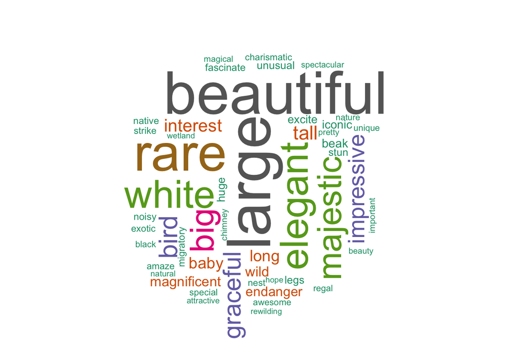

```r
# Create corpus, lemmatise and remove english stopwords
corpus_words <- Corpus(VectorSource(words_df$Words))
corpus_words <- tm_map(corpus_words, lemmatize_words)
corpus_words <- tm_map(corpus_words, removeWords, stopwords("english")) #removes common english stopwords

# Create a wordcloud
wordcloud(corpus_words, scale=c(5,0.5), max.words=50, random.order=FALSE, rot.per=0.25,
          use.r.layout=FALSE, colors=brewer.pal(10,"Dark2"))
```

```r
# # Code to automatically detect, and combine synonyms (e.g., big and large) for clearer word clouds and frequency analysis
# library(dplyr)
# words_df %>%
#   group_by(syn_group) %>%
#   mutate(sum_word_count = sum(word_count)) %>%
#   filter(rank == 1)
#
# d <- data.frame(Term = row.names(m), word_count = m[,1])
# all_pos <- c("ADJECTIVE", "ADVERB", "NOUN","VERB")
# syns <- vector("list", length(all_pos))
# for(w in seq(nrow(d))){
#   # if sysns of (d$Term[w]) has been calculated skip over current w
#   emf <- getTermFilter("ExactMatchFilter", d$Term[w], TRUE)
#   for(i in seq_along(syns)){
#     terms <- getIndexTerms(all_pos[i], 1, emf)
#     if(is.null(terms)){
#       syns[i] <- NA
#     } else{
#       syns[[i]] <-  getSynonyms(terms[[1]])
#     }
#   }
#   # store the results of syns for current w
# }
```